# Module 4: Data Visualization

Author

Affiliation

Adam Spiegler

University of Colorado Denver

## Additional Reading

- [Chapter 2 Data Cleaning and Exploration](https://jfrench.github.io/LinearRegression/data-cleaning-and-exploration.html) from *A Progressive Introduction to Linear Models*
- [Chapters 9-11 R for Data Science: Visualization](https://r4ds.hadley.nz/layers.html)
- [An Overview of Plotting Data in R](https://aspiegler.github.io/Applied-Regression/C-Overview-of-Plots.html) for more details about creating plots in base R.
- The [R Graph Gallery](https://r-graph-gallery.com/) has examples of many other types of graphs.
- Optional: [Interactive Plots with `plotly`](https://aspiegler.github.io/Data-Wrangling-and-Visualization/11-Interactive-Graphics-with-plotly.html) materials from Math 3376

# Loading Required Packages

```r
library(tidyverse)  # load core tidyverse packages
library(ggthemes)  # additional color palettes for ggplot integration
library(plotly)  # package for interactive plots
#library(janitor)  # maybe used for data cleaning
```

**Note**

Recall you only need to install a package with the `install.packages()` function one time on your computer. However, each time you start a new R session, you need to load the package with the `library()` function. Run `install.packages()` commands from the console below and do not include those commands in a R code chunk in your Quarto document. If you get an error message after running the code chunk above, it is possible you first need to install one or more of the packages.

# Exploratory Data Analysis

**Exploratory data analysis**, or **EDA** for short, can be thought of as a cycle:

- Generate questions about our data.
- Search for answers by visualizing, transforming, and modeling our data.
- Use what we learn to refine your questions and/or generate new questions.

The main goal of EDA is to develop an understanding of your data. When we ask a question, the question focuses our attention on a specific part of the data set and helps us decide which graphs, models, or transformations to make.

- EDA can be an intricate process that requires developing some keen investigation skills.
- EDA can be creating one plot that tells a compelling story about the data.
- [Exploratory Data Analysis with R](https://bookdown.org/rdpeng/exdata/) by Roger Peng is a free textbook to help you dig deeper into EDA if interested!

# Tips for Good Graphics

Data graphics should be as *informative* as possible.

- Graphics do *not* need to contain as much *information* as possible.
- Make it as easy to understand the information you want to reveal about the data.
- Simpler graphics are easier to understand and should be preferred.
- Adding complexity to a graphic can sometimes reveal far more about the data than a simple graphic.
- Make sure labels and text are large enough to easily read.
- Make sure colors are distinguishable and colorblind friendly using the `viridis` color palette.

Complicated graphics may present far more information than we are able to process. You will have to decide what is needed in a graphic to make it as informative as possible.

# Choosing Colors

Choosing a color palette, line style, and/or shapes to represent the attributes with our plots can be very critical. Moreover, being able to choose visual aids that are accessible to individuals that see colors differently helps make your plots insightful for a general audience.

- The traditional color palettes available in R are `rainbow`, `heat.colors`, `terrain.colors`, `topo.colors`, and `cm.colors`.

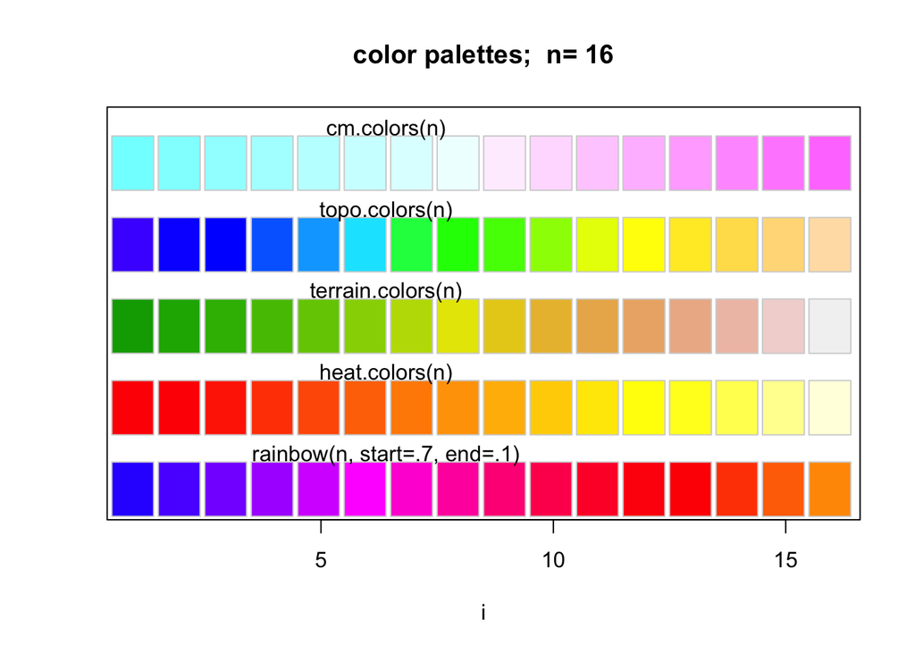

- The `hcl.colors` palette function was added in R 4.0.0 and provides numerous excellent color palettes that are included in the appendix at the end of this module.

[figure not shown]

- Running the examples in the documentation found in `?grDevices::hcl.colors` will show examples of the available palettes through `grDevices`.
- There are color swatches for many palettes in the appendices at the end of this module.
- The [`colorspace`](https://cran.r-project.org/web/packages/colorspace/vignettes/colorspace.html) package provides many of the same HCL palettes available through the `hcl.colors` palette, but it also provides convenient functions for accessing this in `ggplot2`.

# Example: Modeling HDI and Electricity Consumption Data

## About the HDI Data

The Human Development Index (HDI) data is from the [United Nations Development Programme](https://undp.org/) that oversees the calculation of HDI based on the following stated criteria:

> The Human Development Index (HDI) is a summary measure of average achievement in key dimensions of human development: a long and healthy life, being knowledgeable and having a decent standard of living. The HDI is the geometric mean of normalized indices for each of the three dimensions.

HDI values are standardized scores from 0 (poor HDI) to 1 (perfect HDI). Data downloaded 3/8/2025 from https://hdr.undp.org/data-center/human-development-index#/indicies/HDI,

## About the Electricity Consumption Data

Electricity consumption data contains the electricity use per capita in kilowatt-hours per capita (kWh per capita) for all countries in the world (for which there is data) over the years 1960-2023 (though most countries last reported data in 2014). The data is from the [World Bank Databank](https://data.worldbank.org/). Data downloaded 3/8/2025 from https://data.worldbank.org/indicator/EG.USE.ELEC.KH.PC/countries.

## Visually Exploring the Data

First we import and expect the data.

```r
# creates data frame from csv file
hdi_elec_all <- read_rds("https://raw.githubusercontent.com/aspiegler/Applied-Regression/main/Data/hdi_electric.rds")
str(hdi_elec_all)
```

```
tibble [14,528 × 7] (S3: tbl_df/tbl/data.frame)
 $ country        : Factor w/ 243 levels "Afghanistan",..: 1 1 1 1 1 1 1 1 1 1 ...
 $ year           : int [1:14528] 1960 1961 1962 1963 1964 1965 1966 1967 1968 1969 ...
 $ electricity_use: num [1:14528] NA NA NA NA NA NA NA NA NA NA ...
 $ hdi            : num [1:14528] NA NA NA NA NA NA NA NA NA NA ...
 $ country_code   : Factor w/ 218 levels "ABW","AFG","AGO",..: 2 2 2 2 2 2 2 2 2 2 ...
 $ region         : Factor w/ 7 levels "East Asia & Pacific",..: 4 4 4 4 4 4 4 4 4 4 ...
 $ income_group   : Factor w/ 4 levels "High income",..: 2 2 2 2 2 2 2 2 2 2 ...
```

Let’s filter out the data we want to work with.

```r
# filter only observations for 2014
hdi_elec <- hdi_elec_all[hdi_elec_all$year == 2014, ]  # you can use base R
#hdi_elec <- filter(hdi_elec_all, year == 2014)  # you can use dplyr
print(hdi_elec)
```

```
# A tibble: 237 × 7
   country          year electricity_use    hdi country_code region income_group
   <fct>           <int>           <dbl>  <dbl> <fct>        <fct>  <fct>
 1 Afghanistan      2014             NA   0.479 AFG          Middl… Low income
 2 Albania          2014           2309.  0.792 ALB          Europ… Upper middl…
 3 Algeria          2014           1353.  0.735 DZA          Middl… Upper middl…
 4 American Samoa   2014             NA  NA     ASM          East … High income
 5 Andorra          2014             NA   0.871 AND          Europ… High income
 6 Angola           2014            310.  0.563 AGO          Sub-S… Lower middl…
 7 Antigua and Ba…  2014             NA   0.789 ATG          Latin… High income
 8 Argentina        2014           3049.  0.846 ARG          Latin… Upper middl…
 9 Armenia          2014           1896.  0.764 ARM          Europ… Upper middl…
10 Aruba            2014             NA  NA     ABW          Latin… High income
# ℹ 227 more rows
```

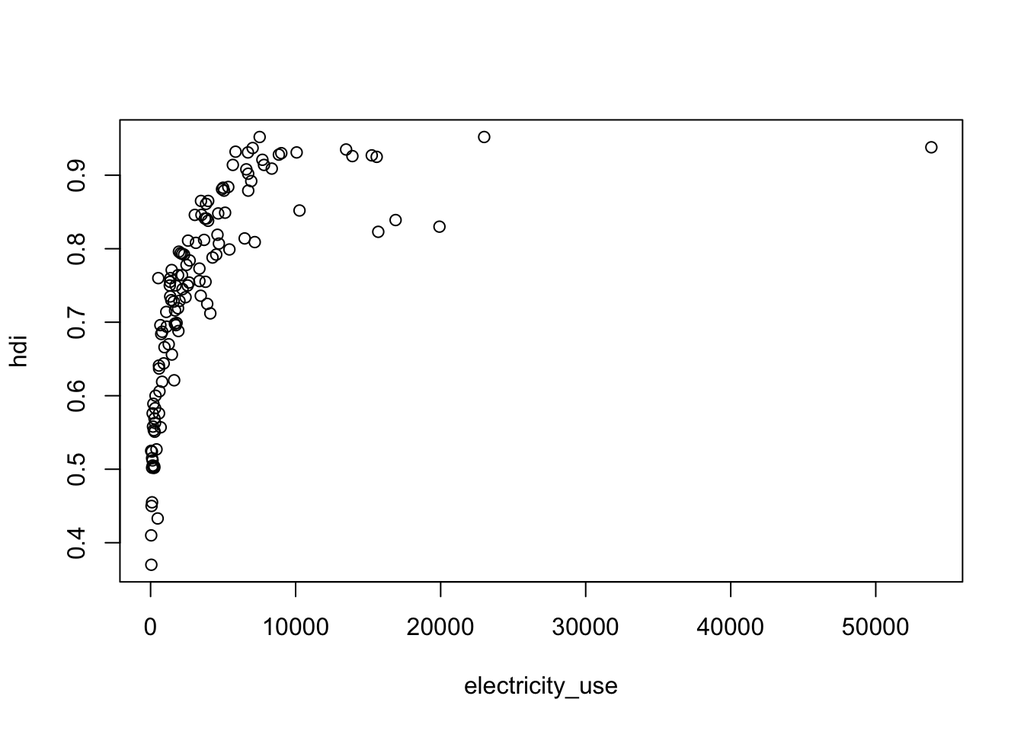

```r
# as electricity consumption goes up so does hdi
# but there is an outlier that makes it hard to see others
plot(hdi ~ electricity_use, data = hdi_elec)
```

```r
# who is the outlier?
slice_max(hdi_elec, electricity_use, n = 5)
```

[output not shown]

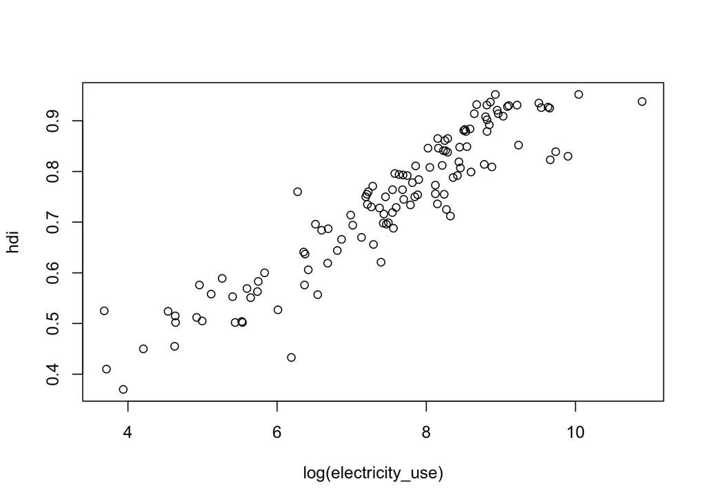

```r
# transform electricity_use before building linear model makes sense
# looks like a pretty strong linear relation
plot(hdi ~ log(electricity_use), data = hdi_elec)
```

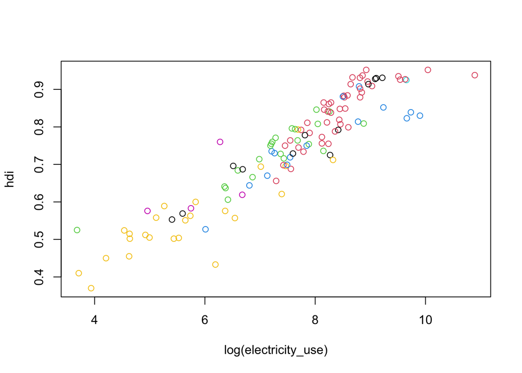

```r
# adding region to the plot
plot(hdi ~ log(electricity_use),
     data = hdi_elec,
     col = region)
```

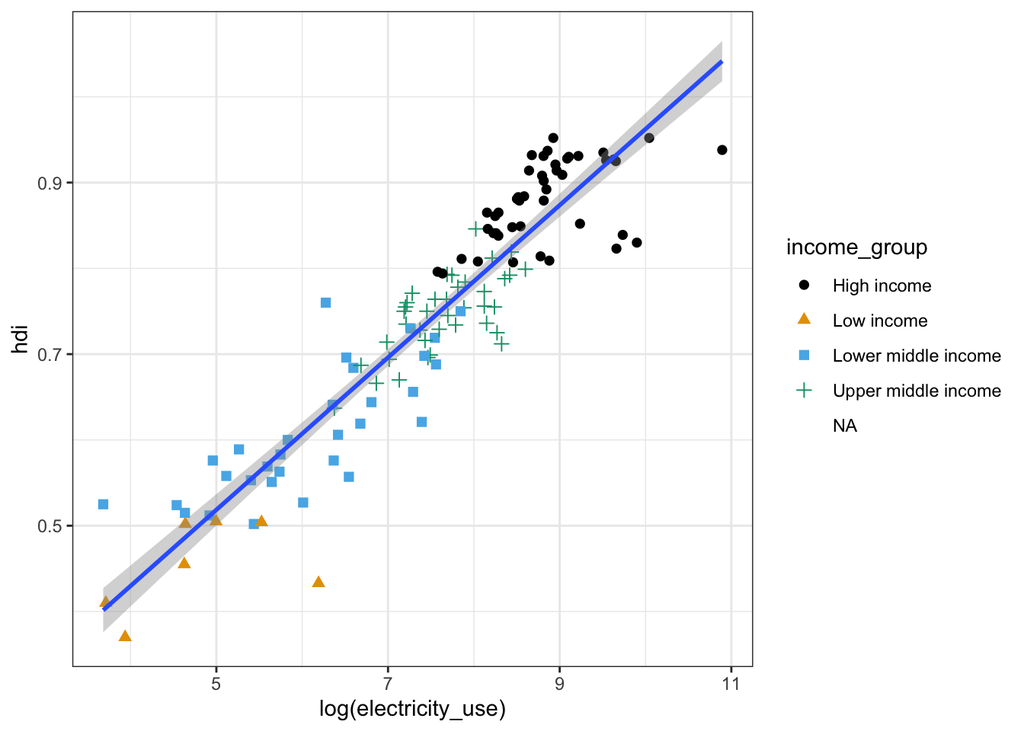

```r
gghdi <- ggplot(hdi_elec, aes(x = log(electricity_use), y = hdi)) +
  geom_point(aes(color = income_group, shape = income_group), size = 2) +  # create scatter plot
  geom_smooth(method = "lm") +  # add smoother
  scale_color_colorblind() +  # adjust color palette for more accesible colors
  theme_bw()

gghdi
```

```r
# interactive plot, but labels not ideal
ggplotly(gghdi)
```

[interactive chart not shown]

```r
gghdi_2 <- ggplot(hdi_elec, aes(x = log(electricity_use), y = hdi)) +
  geom_point(aes(color = income_group, shape = income_group, text = country), size = 2) +  # create scatter plot
  geom_smooth(method = "lm") +  # add smoother
  scale_color_colorblind() +  # adjust color palette for more accesible colors
  theme_bw()

ggplotly(gghdi_2,
         tooltip = c("text", "x", "y", "region"))
```

[interactive chart not shown]

# Hawks Data

```r
hawks <- read_rds("https://raw.githubusercontent.com/aspiegler/Applied-Regression/main/Data/hawks_clean.rds")
glimpse(hawks)
```

```
Rows: 908
Columns: 19
$ month         <int> 9, 9, 9, 9, 9, 9, 9, 9, 9, 9, 10, 10, 10, 10, 10, 10, 10…
$ day           <int> 19, 22, 23, 23, 27, 28, 28, 29, 29, 30, 5, 8, 9, 10, 11,…
$ year          <int> 1992, 1992, 1992, 1992, 1992, 1992, 1992, 1992, 1992, 19…
$ capture_time  <fct> 13:30, 10:30, 12:45, 10:50, 11:15, 11:25, 13:30, 11:45, …
$ release_time  <fct> NA, NA, NA, NA, NA, NA, NA, NA, NA, NA, NA, NA, NA, NA, …
$ band_number   <fct> 877-76317, 877-76318, 877-76319, 745-49508, 1253-98801, …
$ species       <fct> RT, RT, RT, CH, SS, RT, RT, RT, RT, RT, RT, RT, RT, RT, …
$ age           <fct> I, I, I, I, I, I, I, A, A, I, I, I, A, A, I, A, I, A, I,…
$ sex           <fct> NA, NA, NA, F, F, NA, NA, NA, NA, NA, NA, NA, NA, NA, NA…
$ wing          <dbl> 385, 376, 381, 265, 205, 412, 370, 375, 412, 405, 393, 3…
$ weight        <dbl> 920, 930, 990, 470, 170, 1090, 960, 855, 1210, 1120, 101…
$ culmen        <dbl> 25.7, NA, 26.7, 18.7, 12.5, 28.5, 25.3, 27.2, 29.3, 26.0…
$ hallux        <dbl> 30.1, NA, 31.3, 23.5, 14.3, 32.2, 30.1, 30.0, 31.3, 30.2…
$ tail          <dbl> 219, 221, 235, 220, 157, 230, 212, 243, 210, 238, 222, 2…
$ standard_tail <dbl> NA, NA, NA, NA, NA, NA, NA, NA, NA, NA, NA, NA, NA, NA, …
$ tarsus        <dbl> NA, NA, NA, NA, NA, NA, NA, NA, NA, NA, NA, NA, NA, NA, …
$ wing_pit_fat  <dbl> NA, NA, NA, NA, NA, NA, NA, NA, NA, NA, NA, NA, NA, NA, …
$ keel_fat      <dbl> NA, NA, NA, NA, NA, NA, NA, NA, NA, NA, NA, NA, NA, NA, …
$ crop          <dbl> NA, NA, NA, NA, NA, NA, NA, NA, NA, NA, NA, NA, NA, NA, …
```

The data frame `hawks`has 908 observations on 19 variables. Some of the variables we will consider are:

- `species`: `CH` = Cooper’s, `RT` = Red-tailed, `SS` = Sharp-Shinned
- `age`: `I` = Immature or `A` = Adult
- `sex`: `F` = Female or `M` = Male
- `wing`: Length (in mm) of primary wing feather from tip to wrist it attaches to
- `weight`: Body weight (in g)
- `culmen`: Length (in mm) of the upper bill from the tip to where it bumps into the fleshy part of the bird
- `hallux`: Length (in mm) of the killing talon
- `tail`: Measurement (in mm) related to the length of the tail (invented at the MacBride Raptor Center)
- `standard_tail`: Standard measurement of tail length (in mm)
- `tarsus`: Length of the basic foot bone (in mm)
- `wing_pit_fat`: Amount of fat in the wing pit
- `keel_fat`: Amount of fat on the breastbone (measured by feel)

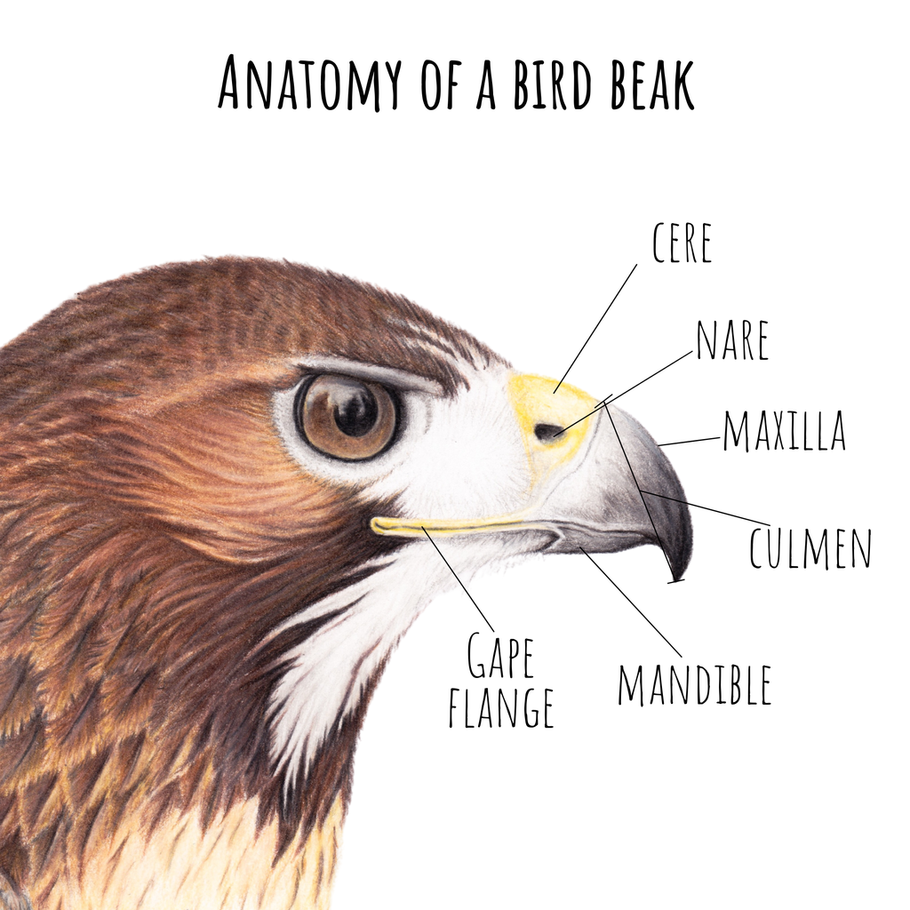

anatomy-bird-beak

# Numeric Summaries of Variables

- [See text section 2.3](https://jfrench.github.io/LinearRegression/data-cleaning-and-exploration.html#numerical-summarization-of-data)
- [See Statistical Theory Materials](https://aspiegler.github.io/Statistical-Theory/02-EDA-Categorical.html)

Numerical exploration of a data set generally consists of computing various relevant statistics for each of the variables in a data set in order to summarize the data.

| numeric summary | variable type | summarizes | R function |
| --- | --- | --- | --- |
| mean | `numeric` | center | `mean` |
| median | `numeric` | center | `median` |
| variance | `numeric` | spread | `var` |
| standard deviation | `numeric` | spread | `sd` |
| interquartile range | `numeric` | spread | `IQR` |
| quantiles | `numeric` | center and spread | `quantile` |
| correlation | `numeric` | similarity | `cor` |
| frequency distribution | `factor` | counts | `table` |
| relative frequency distribution | `factor` | proportions | `prop.table` |

## The `summary()` Function

The `summary()` function is one of our favorite R commands by now. It provides a numerical summary for a single vector or for all columns of a data frame at once. The `summary()` function gives a different summary depending on the data type. For example, the output for `numeric` `factor`, or `character` variables are totally different.

```r
summary(hawks)
```

```
     month             day             year       capture_time  release_time
 Min.   : 8.000   Min.   : 1.00   Min.   :1992   13:30  : 14   14:50  :  2
 1st Qu.: 9.000   1st Qu.: 9.00   1st Qu.:1995   11:35  : 14   11:00  :  2
 Median :10.000   Median :16.00   Median :1999   11:45  : 13   12:50  :  2
 Mean   : 9.843   Mean   :15.74   Mean   :1998   12:10  : 13   14:45  :  2
 3rd Qu.:10.000   3rd Qu.:23.00   3rd Qu.:2001   14:00  : 13   12:05  :  2
 Max.   :11.000   Max.   :31.00   Max.   :2003   (Other):840   (Other): 55
                                                 NA's   :  1   NA's   :843
     band_number  species  age       sex           wing           weight
 877-76317 :  1   RT:577   A:224   F   :174   Min.   : 37.2   Min.   :  56.0
 877-76318 :  1   CH: 70   I:684   M   :158   1st Qu.:202.0   1st Qu.: 185.0
 877-76319 :  1   SS:261           NA's:576   Median :370.0   Median : 970.0
 745-49508 :  1                               Mean   :315.6   Mean   : 772.1
 1253-98801:  1                               3rd Qu.:390.0   3rd Qu.:1120.0
 (Other)   :901                               Max.   :480.0   Max.   :2030.0
 NA's      :  2                               NA's   :1       NA's   :10
     culmen         hallux            tail       standard_tail
 Min.   : 8.6   Min.   :  9.50   Min.   :119.0   Min.   :115.0
 1st Qu.:12.8   1st Qu.: 15.10   1st Qu.:160.0   1st Qu.:162.0
 Median :25.5   Median : 29.40   Median :214.0   Median :215.0
 Mean   :21.8   Mean   : 26.41   Mean   :198.8   Mean   :199.2
 3rd Qu.:27.3   3rd Qu.: 31.40   3rd Qu.:225.0   3rd Qu.:226.0
 Max.   :39.2   Max.   :341.40   Max.   :288.0   Max.   :335.0
 NA's   :7      NA's   :6                        NA's   :337
     tarsus       wing_pit_fat       keel_fat          crop
 Min.   :24.70   Min.   :0.0000   Min.   :0.000   Min.   :0.0000
 1st Qu.:55.60   1st Qu.:0.0000   1st Qu.:2.000   1st Qu.:0.0000
 Median :79.30   Median :1.0000   Median :2.000   Median :0.0000
 Mean   :71.95   Mean   :0.7922   Mean   :2.184   Mean   :0.2345
 3rd Qu.:87.00   3rd Qu.:1.0000   3rd Qu.:3.000   3rd Qu.:0.2500
 Max.   :94.00   Max.   :3.0000   Max.   :4.000   Max.   :5.0000
 NA's   :833     NA's   :831      NA's   :341     NA's   :343
```

## Quantitative Variables

Numerical exploration of a set of quantitative (`numeric`) values usually focuses on determining the:

1. center
2. spread
3. quantiles/percentiles
4. correlation (between two different variables)

## Question 1

Use R commands to calculate the mean, median, and standard deviation of the culmen length of all hawks in the sample. Then interpret the practical meaning of these numerical summaries. Include units in your interpretation when possible.

**Tip**

If you get an error message or output that does not make sense at first, you can access help documentation with commands such as `?mean` that might help you correct the error.

### Solution to Question 1

```r
mean(hawks$culmen, na.rm = TRUE)
```

```
[1] 21.8015
```

```r
median(hawks$culmen, na.rm = TRUE)
```

```
[1] 25.5
```

```r
sd(hawks$culmen, na.rm = TRUE)
```

```
[1] 7.284175
```

The average culmen length is $21.8015$ mm. The median culmen length is $25.5$ mm. Thus, half of the hawks in our sample have a culmen length less than $25.5$ mm, and half have a culmen length greater than $25.5$ mm. Since the mean is less than the median, this means the data is skewed to the left (most values are on the right, but a tail of outliers exist on the left). There are some outliers with very small culmen lengths.

The standard deviation is approximately $7.28$ mm. This roughly means the average distance of each culmen length to the mean culmen length is $7.28$ mm. The previous sentence may not sound to practical. We can informally say “many” of the culmen values are $21.8015$ mm $\pm 7.28$ mm, or “most” are between $21.8015$ mm $\pm 2(7.28)$ mm.

**Note**

In the interpretation of the standard deviation, we roughly apply what is often called the 68%-95%-99.5% Rule or the *Empirical Rule* which says if a distribution is normally distributed then: 68% of the data is within $\pm 1$ standard deviation from the mean, 95% of the data is within $\pm 2$ standard deviations from the mean, and 99.5% of the data is within $\pm 3$ standard deviations from the mean. The less normal the data is distributed, the less accurate this rule becomes.

## Question 2

Subset or slice the data into two different data frames:

- The data frame `immature` contains all columns for just the rows with `age` value equal to the `I`.
- The data frame `adult` contains all columns for just the rows with `age` value equal to the `A`.

Comment on how large the sample of immature and the sample of adult hawks are. Then calculate the $0.9$ quantiles for culmen length of the adult hawks and the immature hawks, separately. Interpret the values and comment on how the quantiles compare to each other.

### Solution to Question 2

```r
# subsetting the data
immature <- hawks[hawks$age == "I", ]  # using indexing and logicals
adult <- filter(hawks, age == "A")  # using dplyr
#adult <- subset(hawks, age == "I")  # using base::subset
```

```r
nrow(immature) # number of rows equals data frame is number obs
```

```
[1] 684
```

```r
length(adult$age)  # length of a vector also gives number obs
```

```
[1] 224
```

```r
quantile(immature$culmen, probs = 0.9, na.rm = TRUE)
```

```
 90%
28.7
```

```r
quantile(adult$culmen, 0.9, na.rm = TRUE)  # don't need to name probs arg, it is implied
```

```
  90%
29.08
```

There are a total of 684 immature hawks in the data and 224 adult hawks in the data. 90% of all immature hawks in the sample had a culmen length less than $28.7$ mm. 90% of all adult hawks in the sample had a culmen length less than $29.08$ mm. The 90th percentile for culmen length of adults is slightly ($0.38$ mm) higher compared to immature hawks. Intuitively it makes sense the immature hawks have smaller culmen lengths than adult hawks.

## Question 3

Find the five number summary for culmen length for the sample of adult hawks and the sample of immature hawks. Then interpret the practical mean of the five number summary of the immature hawks.

### Solution to Question 3

```r
summary(immature)
```

```
     month             day             year       capture_time  release_time
 Min.   : 9.000   Min.   : 1.00   Min.   :1992   13:30  : 11   14:50  :  2
 1st Qu.: 9.000   1st Qu.: 9.00   1st Qu.:1995   11:00  : 11   11:00  :  2
 Median :10.000   Median :16.00   Median :1999   13:35  : 10   12:50  :  2
 Mean   : 9.779   Mean   :15.89   Mean   :1998   11:35  : 10   14:45  :  2
 3rd Qu.:10.000   3rd Qu.:23.00   3rd Qu.:2001   13:15  :  9   12:05  :  2
 Max.   :11.000   Max.   :31.00   Max.   :2003   (Other):632   (Other): 48
                                                 NA's   :  1   NA's   :626
     band_number  species  age       sex           wing           weight
 877-76317 :  1   RT:454   A:  0   F   :115   Min.   : 37.2   Min.   :  85.0
 877-76318 :  1   CH: 38   I:684   M   :116   1st Qu.:204.0   1st Qu.: 188.0
 877-76319 :  1   SS:192           NA's:453   Median :371.0   Median : 971.0
 745-49508 :  1                               Mean   :319.4   Mean   : 780.1
 1253-98801:  1                               3rd Qu.:390.0   3rd Qu.:1120.0
 (Other)   :678                               Max.   :469.0   Max.   :2030.0
 NA's      :  1                                               NA's   :7
     culmen          hallux            tail       standard_tail
 Min.   : 8.60   Min.   :  9.50   Min.   :122.0   Min.   :115.0
 1st Qu.:12.70   1st Qu.: 15.20   1st Qu.:161.0   1st Qu.:162.2
 Median :25.70   Median : 29.60   Median :217.0   Median :219.0
 Mean   :21.98   Mean   : 26.65   Mean   :201.4   Mean   :201.6
 3rd Qu.:27.30   3rd Qu.: 31.50   3rd Qu.:227.0   3rd Qu.:230.0
 Max.   :34.10   Max.   :341.40   Max.   :288.0   Max.   :335.0
 NA's   :6       NA's   :5                        NA's   :266
     tarsus       wing_pit_fat       keel_fat          crop
 Min.   :44.50   Min.   :0.0000   Min.   :0.000   Min.   :0.0000
 1st Qu.:55.95   1st Qu.:0.0000   1st Qu.:1.000   1st Qu.:0.0000
 Median :79.30   Median :1.0000   Median :2.000   Median :0.0000
 Mean   :72.08   Mean   :0.7681   Mean   :2.073   Mean   :0.2189
 3rd Qu.:86.85   3rd Qu.:1.0000   3rd Qu.:3.000   3rd Qu.:0.2500
 Max.   :94.00   Max.   :3.0000   Max.   :4.000   Max.   :5.0000
 NA's   :617     NA's   :615      NA's   :269     NA's   :270
```

```r
# returns just the 5 numbers
# NA's are filtered out by default, yay!
fivenum(immature$culmen)
```

```
[1]  8.6 12.7 25.7 27.3 34.1
```

- The five number summary for culmen length of the immature hawks is $(8.6, 12.7, 25.7, 27.3, 34.1)$.

25% of all immature hawks in the sample have a culmen length between each pair of successive values in the five number of summary. In other words:

- One-quarter of the immature hawks in the sample have a culmen length between $8.6$ mm and $12.7$ mm.
- $25\%$ of the immature hawks in the sample have a culmen length between $12.7$ mm and $25.7$ mm.
- And so on.
- The middle 50% of the immature hawks in the sample have a culmen length between $12.7$ and $27.3$ mm.

**Note**

The distance between the first and third quartiles, denoted $Q_1$ and $Q_3$ respectively, is called the **interquartile range** or **IQR**. It gives the width of the spread of the middle 50% of values in the data. In R, we can calculate the IQR with `IQR()`.

```r
# comparing two methods
# need to specify to remove na
IQR(immature$culmen, na.rm = TRUE)
```

```
[1] 14.6
```

```r
quantile(immature$culmen, 0.75, na.rm = TRUE) - # Q3 -
  quantile(immature$culmen, 0.25, na.rm = TRUE)  # Q1
```

```
 75%
14.6
```

```r
# includes additional info
# NA's are also filtered out by default
summary(adult$culmen)
```

```
   Min. 1st Qu.  Median    Mean 3rd Qu.    Max.    NA's
   9.30   12.95   25.30   21.26   27.50   39.20       1
```

```r
# finding each value separately
min(adult$culmen, na.rm = TRUE)  # find minimum value
```

```
[1] 9.3
```

```r
quantile(adult$culmen, 0.25, na.rm = TRUE)  # Q1 = 0.25 quantile
```

```
  25%
12.95
```

```r
median(adult$culmen, na.rm = TRUE)  # find minimum value
```

```
[1] 25.3
```

```r
quantile(adult$culmen, 0.75, na.rm = TRUE)  # Q3 = 0.75 quantile
```

```
 75%
27.5
```

```r
max(adult$culmen, na.rm = TRUE)  # find minimum value
```

```
[1] 39.2
```

- The five number summary for culmen length of the adult hawks is $(9.3, 12.95, 25.3, 27.5, 39.2)$.

### Notation and Terminology

- For a **sample**, we use $\bar{x}$ and $s$ to denote the mean and standard deviation, respectively. These are **statistics** since they summarize a sample.
- For a **population**, we use Greek letters $\mu$ and $\sigma$ to denote the mean and standard deviation. These are **parameters** since they summarize a population.
- When performing **statistical inference**, usually the values of the parameters are unknown, but we can estimate their values using statistics that we measure from a sample.
- Since there is randomness in the sampling process, estimates will vary from sample to sample, and we should build some **uncertainty** into our estimates.

For samples, we have the formulas

$$\bar{x} = \frac{x_1 + x_2 + \ldots + x_n}{n} = \frac{\sum_{i=1}^n x_i}{n}$$
and

$$s = \sqrt{\frac{\sum (x_i - \bar{x})^2}{n-1}}.$$

### Correlation

The correlation between two `numeric` variables quantifies the strength and direction of their linear relationship.

The most common correlation statistic is Pearson’s correlation statistic (or **correlation coefficient**). If $x_1, x_2, \ldots, x_n$ and $y_1, y_2, \ldots, y_n$ are two sets of `numeric` values, then the sample correlation statistic is computed as

$$r = \frac{1}{n-1}\sum_{i=1}^n\left(\frac{x_i - \bar{x}}{s_x}\right)\left(\frac{y_i - \bar{y}}{s_y}\right),$$

where:

- $\bar{x}$ and $s_x$ denote the sample mean and standard deviation of the $x$’s.
- $\bar{y}$ and $s_y$ denote the same thing for the $y$’s.

$r$ must be between -1 and 1.

The `cor` function can be used to compute the sample correlation between two `numeric` variables.

**Note**

The typical convention of using Greek letters for population parameters and Latin letters for sample statistics applies to correlation. Namely we use $r$ for a correlation coefficient of a sample and $\rho$ for a correlation coefficient for population data.

#### Interpreting the Value of the Correlation Coefficient

- The closer $r$ is to $-1$ or $1$, the closer the data values are to a straight line.
- $r$ values close to 0 indicate that there is no linear relationship between the two variables.
- Negative $r$ values indicate a negative relationship between the two variables (as values of one variable increase, the values of the other variable tend to decrease).
- Positive $r$ values indicate a positive relationship between the two variables (as values of one variable increase, the values of the other variable also tend to increase).

## Question 4

In the code below, we compute the sample correlation between the `wing` and `tail` variables in `hawks`. Notice the argument `use = "complete.obs"` is used to remove any observations with either a missing `wing` or `tail` value before calculating the correlation. Interpret the practical meaning of the correlation coefficient.

```r
# determine whether each variable is numeric
cor(hawks$wing, hawks$tail, use = "complete.obs")
```

```
[1] 0.900054
```

### Solution to Question 4

We see there is a positive association between `wing` and `tail` lengths of hawks. This makes sense since we’d expect as a hawk’s `wing` length grows, its `tail` length would also tend to grow. The fact that the value is close to 1 means the association should be close to linear. We expect a plot of the points to be approximately linear and going up with a roughly constant, positive slope.

## Question 5

Insert a code cell below to calculate the correlation between hawk `wing` and the `year`. Then interpret the value of the result. Does the result align or contradict your intuition?

### Solution to Question 5

```r
# determine whether each variable is numeric
cor(hawks$wing, hawks$year, use = "complete.obs")
```

```
[1] -0.204111
```

The correlation coefficient is $r = -0.204111$. The value is negative which means there is a negative association between the variables. For example, as the time goes on (`year` increases) the `wing` lengths tend to get smaller. The value is close to 0 which there is not a strong linear association. We might expect a plot of the points to be more a cloud of data rather than see a pattern.

## Categorical (or Qualitive) Data

### Frequency Tables

Tables of frequencies (or counts) are useful for determining how many observation are in each class of a categorical variable. We can use the `table()` function to get the distribution of frequencies.

```r
# table function returns counts for one variable
table(hawks$age)  # na values removed by default
```

```
  A   I
224 684
```

### Contingency (Two-Way) Tables

A **contingency table** (or **two-way table**) gives the number of observations in BOTH a specified class of one variable AND another specified class of a second variable.

## Question 6

Run the code cell below to generate a two-way that shows the relationship between the `age` and `species` variables. Which species has the most adult hawks? Which species has the most immature hawks?

```r
# table function returns two-way table to compare 2 categorical variables
table(hawks$age, hawks$species)
```

```
     RT  CH  SS
  A 123  32  69
  I 454  38 192
```

### Relative Frequency Tables

A **relative frequency table summarizes** the proportion or percentage of observations with each level of a categorical variable.

**Note**

Relative frequencies typically provide more context and are more meaningful when comparing data that is not uniformly distributed. When some classes have a lot of observations and others few, comparing counts can be misleading.

```r
my_tbl <- table(hawks$age)
my_tbl
```

```
  A   I
224 684
```

```r
prop.table(my_tbl)
```

```
       A        I
0.246696 0.753304
```

### Joint Distributions and Marginal Distributions

When we apply the `prop.table(two_way_tbl)` function to a two-way table stored in `two_way_tbl`, the output tells us what proportion of all observations in the data frame are both a specified class of one variable and a specified class of a second variable. **By default the proportions are calculated relative to the grand total**. In other words, we divide each of the counts in `two_way_tbl` by the total number of all observations. The resulting table gives the **joint distribution** for variables `age` and `species`.

```r
# table function returns two-way table to compare 2 categorical variables
two_way_tbl <- table(hawks$age, hawks$species)
two_way_tbl
```

```
     RT  CH  SS
  A 123  32  69
  I 454  38 192
```

```r
# proportions relative to grand total
prop.table(two_way_tbl) |>
  round(4)  # pipe output into round function to round to 4 decimal places
```

```
        RT     CH     SS
  A 0.1355 0.0352 0.0760
  I 0.5000 0.0419 0.2115
```

```r
# manually divide each count by total number of observations
# returns same result
round(two_way_tbl / nrow(hawks), 4)
```

```
        RT     CH     SS
  A 0.1355 0.0352 0.0760
  I 0.5000 0.0419 0.2115
```

We can compute the relative frequencies relative to either the row totals or the columns totals by adding the option `1` or `2` after entering the table.

- Adding the option 1, `prop.table(two_way_tbl, 1)`, gives proportions relative to the row totals.
  - Each count in `two_way_tbl` is divided by the total count in each row.
  - The sum of the proportions in each row should add up to 1.
  - In our example below, we each proportion is relative to the total number in each `age` group (each row is a different `age` group.)

```r
# adding option 1 to prop.table()
prop.table(two_way_tbl, 1) |>  # proportions are relative to row totals
  round(4)  # round to 4 decimal places
```

```
        RT     CH     SS
  A 0.5491 0.1429 0.3080
  I 0.6637 0.0556 0.2807
```

- Adding the option 2, `prop.table(two_way_tbl, 2)`, gives proportions relative to the column totals.
  - Each count in `two_way_tbl` is divided by the total count in each column.
  - The sum of the proportions in each column should add up to 1.
  - In our example below, we each proportion is relative to the total number in each species (each column is a different `species`.)

```r
# adding option 2 using pipe
table(hawks$age, hawks$species) |>  # first find two-way table (not stored)
  prop.table(2) |>  # then convert to prop relative to col totals
  round(4)  # finally round to 4 decimal places
```

```
        RT     CH     SS
  A 0.2132 0.4571 0.2644
  I 0.7868 0.5429 0.7356
```

## Question 7

Based on the output from the three different `prop.table()` (relative to grand total, row totals, and column totals), answer the following questions and indicate which table was most useful at answering the question.

- If an adult hawk in the sample is randomly selected, which species is the hawk most likely?
- If a Cooper’s hawk in the sample is randomly selected, which age group is it mostly likely in?
- Which species has the greatest proportion of adults hawks in its sample?

### Solution to Question 7

# Visual Summaries of Data

Visual summaries (i.e., plots) of data help us:

- Spot errors in our data, unusual observations, and simple patterns.
- Communicate the results of our analysis.

The two most popular packages for producing graphics in R are:

- `base`: the default graphics system
- `ggplot2`: a “grammar of graphics” that is able to produce complex graphics with automated legends in a consistent, systematic way.

| Visual summary | Variable types | Summary type | Base functions | geoms |
| --- | --- | --- | --- | --- |
| box plot | 1 `numeric` | univariate | `boxplot(x)` | `geom_boxplot` |
| histogram | 1 `numeric` | univariate | `hist(x)` | `geom_histogram` |
| density plot | 1 `numeric` | univariate | `plot(density(x)` | `geom_density` |
| bar plot | `factor` | univariate | `plot(x)` or `barplot(tbl)` | `geom_bar` |
| scatter plot | 2 `numeric` | bivariate | `plot` | `geom_point` |
| side-by-side box plots | 1 `numeric`, 1 `factor` | bivariate | `plot(x, y)` or `boxplot(x, y)` | `geom_boxplot` |
| stacked or grouped bar plot | 2 `factor` | bivariate | `boxplot(prop.table(two_way_tbl))` | `geom_boxplot` |
| grouped scatter plot | 2 `numeric`, 1 `factor` | multivariate | `plot` | `geom_point` |
| faceted plots | mixed | multivariate | none | `facet_wrap` or `facet_grid` |
| interactive plots | mixed | multivariate | none | `plotly::ggplotly` |

## Using the Generic `plot()` function

The base R function `plot()` is the most generic plotting function, and it often does a pretty nice job of getting the ball rolling. Based on the data type and number of of the variables included, R will take an educated guess as to what plot might help visualize features of the data.

- If `fac` is a `factor`, then `plot(fac)` gives a **bar plot**.
- If `num` is a `numeric`, then `plot(num)` gives an **index plot** which is often not helpful.
- If `num` is a `numeric` and `fac` is a `factor`, then `plot(fac, num)` gives **side-by-side box plots**.
- If `num1` and `num2` are two `numeric` vectors, then `plot(num1, num2)` gives a **scatter plot**.
- If `fac1` and `fac2` are two `factor` vectors, then `plot(fac1, fac2)` is **not useful**.

### One Categorical Variable: Bar Plots

Factors such as `species` are plotted using a bar plot which is very reasonable.

```r
# a factor variable results in bar plot
plot(hawks$species)
```

[output not shown]

- Run `?plot()` to see a list of arguments that can be added to the command. Below are some common arguments.
- A `legend()` can also be added to output of a `plot()`. Options are similar to `plot()`. Run `?legend()` for more info.

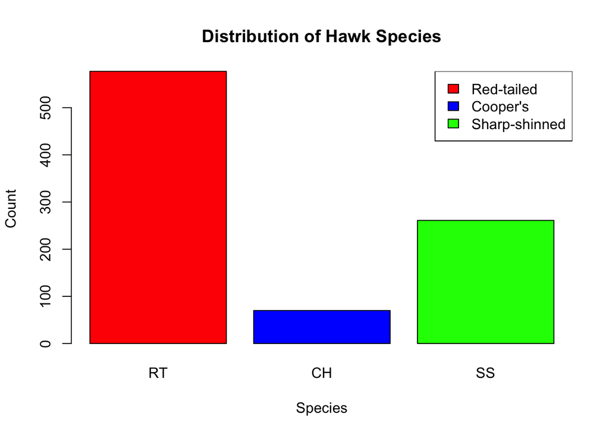

```r
plot(hawks$species,
     main = "Distribution of Hawk Species",  # main title
     xlab = "Species",  # title on x-axis
     ylab = "Count",  # title on y-axis
     col = c("red", "blue", "green"))  # fill colors

# add a legend to plot
legend(x="topright",  # place legend in top right
       legend = c("Red-tailed", "Cooper's", "Sharp-shinned"),
       fill = c("red", "blue", "green"))  # use same fill colors
```

### One Numeric Variable: Index Plot

Numeric variables such as `culmen` are plotted using an index plot which is typically not very useful. Thus, we typically use other functions to plot one numeric variable in most situations.

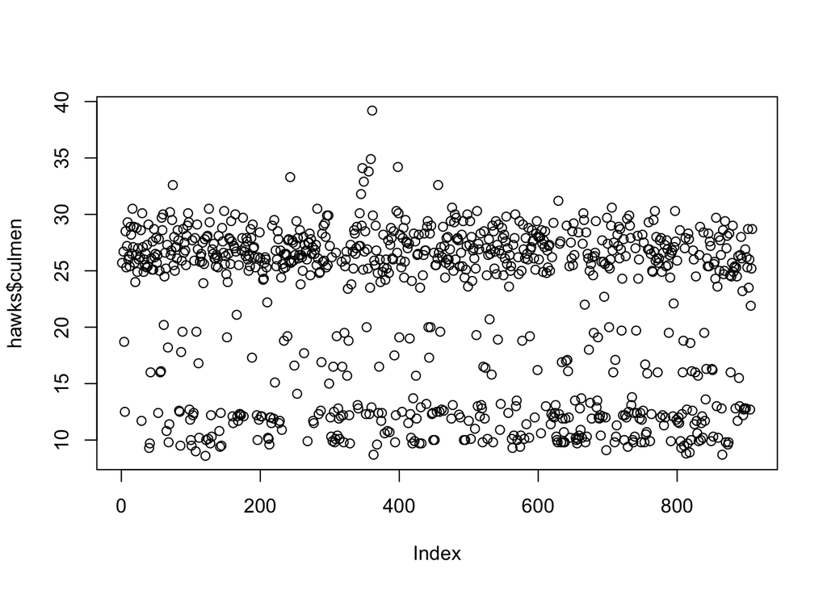

```r
plot(hawks$culmen)
```

## Question 8

Even though the index plot generated by `plot()` is not necessarily the best plot to identify key characteristics, can you identify any patterns or properties in the `culmen` measurements? If so, give a possible reason for observing the pattern.

### Comparing One Numeric and One Categorical Variable: Side-by-Side Box Plots

Entering one categorical (factor) `df$fac` and one quantitative variable `df$num` into the generic `plot(df$fac, df$num)` results in a side by side box plots. One box plot for each class of the categorical variable. This is a very fine choice by R!

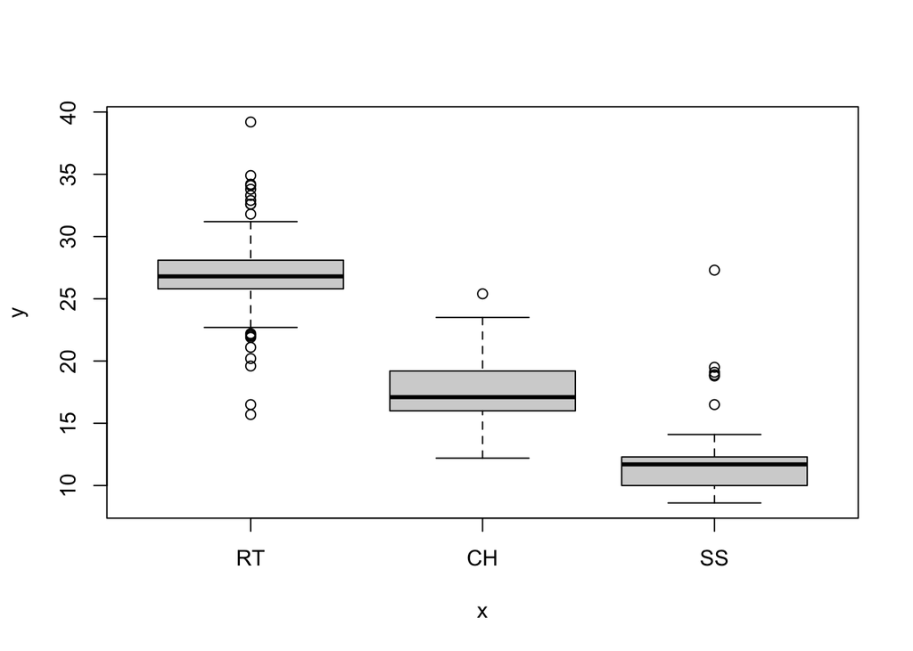

```r
plot(hawks$species, hawks$culmen)
```

**Note**

In the plot below we make use of the topo color palette that is available in `base` R.

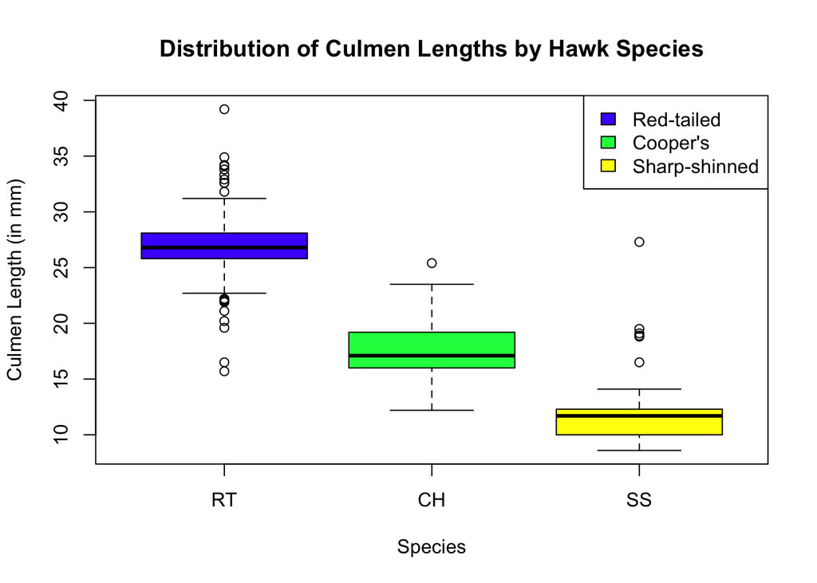

```r
plot(hawks$species, hawks$culmen,
     main = "Distribution of Culmen Lengths by Hawk Species",  # main title
     xlab = "Species",  # title on x-axis
     ylab = "Culmen Length (in mm)",  # title on y-axis
     col = topo.colors(3))  # fill colors

# add a legend to plot
legend(x="topright",  # place legend in top right
       legend = c("Red-tailed", "Cooper's", "Sharp-shinned"),
       fill = topo.colors(3))  # use same fill colors
```

## Question 9

Based on the plot generated by the previous code chunk, do you believe there is a relation between `species` and `culmen` length? If so, summarize the relation.

### Comparing Two Numeric Variables: Scatter Plots

**Scatter plots** can be used to examine the relationship between two `numeric` variables. Entering two numeric variables into the generic `plot(x, y)`results in a scatter plot which is totally reasonable!

- The values from the first vector are plotted on the horizontal axis.
- The values from the second vector are plotted on the vertical axis.
- Each observation is a single point associated with an ordered pair of values.
- The two vectors must have the same length.

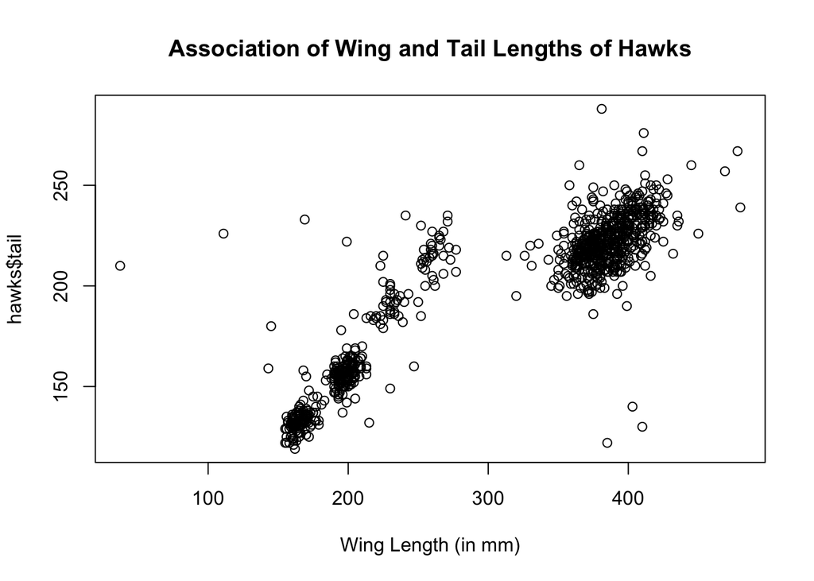

```r
plot(hawks$wing, hawks$tail,
     main = "Association of Wing and Tail Lengths of Hawks",  # main title
     xlab = "Wing Length (in mm)")  # title on x-axis
```

We can also adjust the syntax of the `plot()` function to enter the information as `plot(y ~ x, data = df)`. Notice first we enter the response variable `y` which is plotted on the vertical axis and then the predictor variable `x` which is plotted on the horizontal axis. In this example:

- The response variable is the `numeric` variable, `tail`.
- The predictor variable is the `numeric` variable, `wing`.
- The `data` is `hawks`.

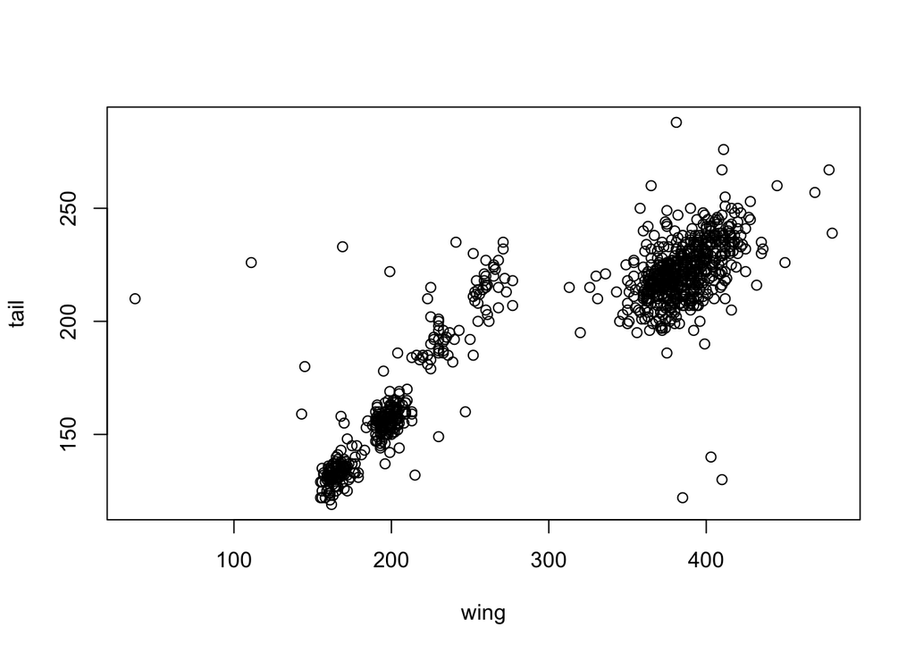

```r
# use the syntax boxplot(response ~ predictor, data = df)
plot(tail ~ wing, data = hawks)
```

## Question 10

Based on the plot generated by the previous code chunk:

- Summarize the general relation between `wing` and `tail` lengths?
- Do you believe there may be other variables lurking in background that are also related to `wing` and `tail`?
- What visual features could we add to the plot to help identify other potential lurking variables?

### Solution to Question 10

### Comparing Two Categorical Variables: Stacked and Grouped Bar Plots

Entering two categorical (factor) variables into the generic `plot()` function does not work very unfortunately. We can create nice visual displays for comparing two categorical variables with the base R `barplot()` function and using the `ggplot2` package. Both methods are discussed shortly.

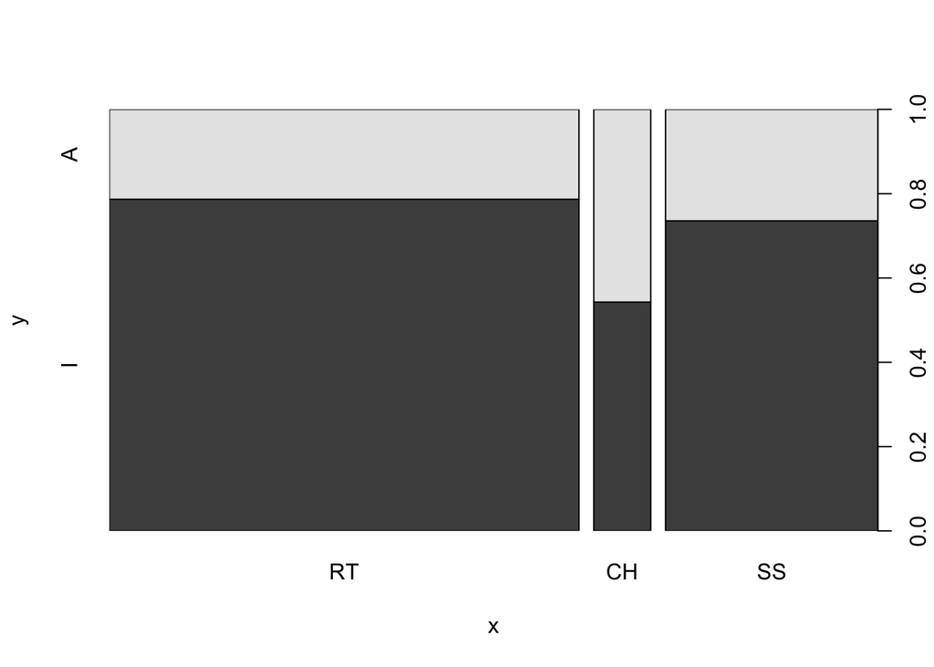

```r
plot(hawks$species, hawks$age)
```

## Base R Plotting Functions

The generic `base` R `plot()` function changes the type of plot based on the data types of the vectors that are input. There are additional `base` R plotting functions available that can create more customized plots. Below are some additional functions we’ll explore:

- `barplot(tbl)` creates a bar plot based on summary stored in `tbl`, including grouped and stacked bar plots if `two_way_tbl` is input.
- `hist(x)` creates a histogram.
- `plot(density(x))` creates a density plot.
- `boxplot(x)` creates box plots (single or side-by-side)

### One Categorical Variable with `barplot()`

We can also convert a frequency table into a bar plot using the `barplot(tbl)` function. This illustrates the different sizes of the samples.

**Caution**

The `barplot()` function must take a table as the input and not a vector. Thus, you must first create a frequency table and then input that table into the `barplot()` function.

```r
# composing functions
barplot(table(hawks$species))
```

[output not shown]

- The pipe is a nice way to compose operations.

```r
# composing actions with the pipe
table(hawks$species) |>
  barplot()
```

[output not shown]

- Run `?barplot()` to see a list of arguments that can be added to the command. Below are some common arguments.
- A `legend()` can also be added to output of a `plot()`. Options are similar to `barplot()`. Run `?legend()` for more info.

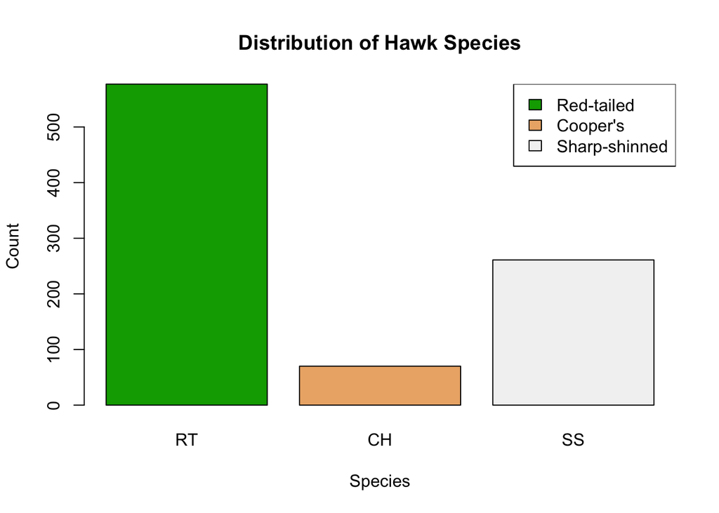

```r
# composing actions with the pipe
table(hawks$species) |>
  barplot(main = "Distribution of Hawk Species",  # main title
          xlab = "Species",  # title on x-axis
          ylab = "Count",  # title on y-axis
          col = terrain.colors(3))  # fill colors)

# add a legend to plot
legend(x="topright",  # place legend in top right
       legend = c("Red-tailed", "Cooper's", "Sharp-shinned"),
       fill = terrain.colors(3))  # use same fill colors
```

### Comparing Two Categorical Variables with `barplot()`

The generic `plot()` function creates a fine looking bar plot when we enter one categorical variable. To compare two categorical variables, the plot was not very useful. Instead, if we create and store a two-way table to `two_way_tbl`, the command the `barplot(two_way_tbl)` will generate a **stacked bar plot**.

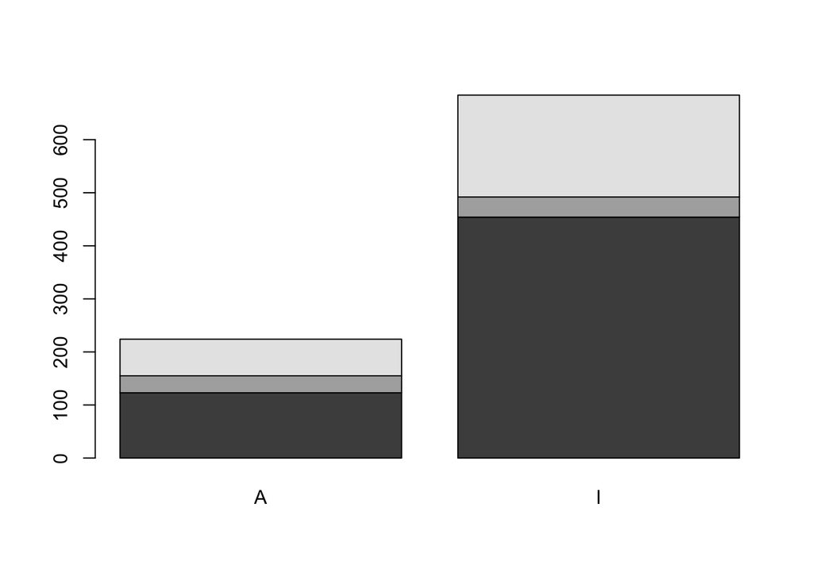

```r
# age on horizontal axis
# different colors stacked for each species
table(hawks$species, hawks$age) |>  # create frequency table
  barplot()  # construct bar plot of counts
```

**Note**

The `hcl.colors` function provides has many additional color palettes. See the appendix for a more complete picture. In the code cell below, we use the `viridis` color palette which is the recommended choice for accessibility.

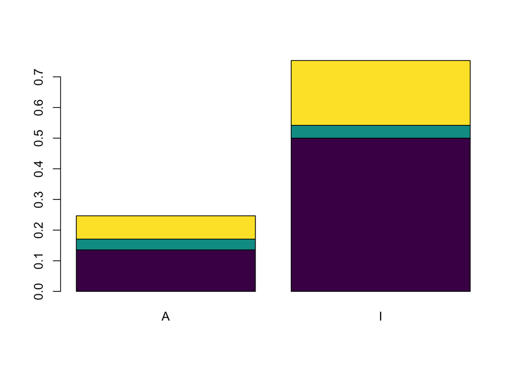

```r
# convert to relative frequencies
num_species <- nlevels(hawks$species)  # nlevels() counts number of levels of species

table(hawks$species, hawks$age) |>  # species are rows and age is column
  prop.table() |>  # compute table of proportions relative to grand total
  barplot(col = hcl.colors(num_species, palette = "viridis"))  # change color of bars
```

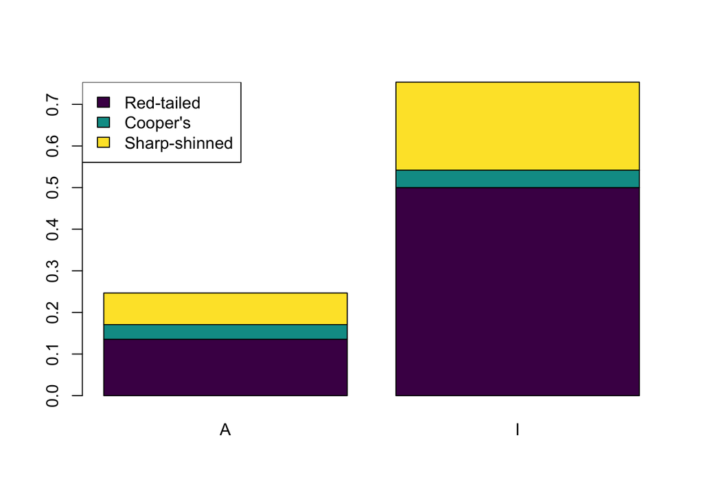

```r
# adding a legend
#num_species <- nlevels(hawks$species)  # nlevels() counts number of levels of species

table(hawks$species, hawks$age) |>
  prop.table() |>
  barplot(col = hcl.colors(num_species, palette = "viridis"))

legend(x="topleft",  # place legend in top left
       legend = c("Red-tailed", "Cooper's", "Sharp-shinned"),
       fill = hcl.colors(num_species, palette = "viridis"))  # use same fill colors
```

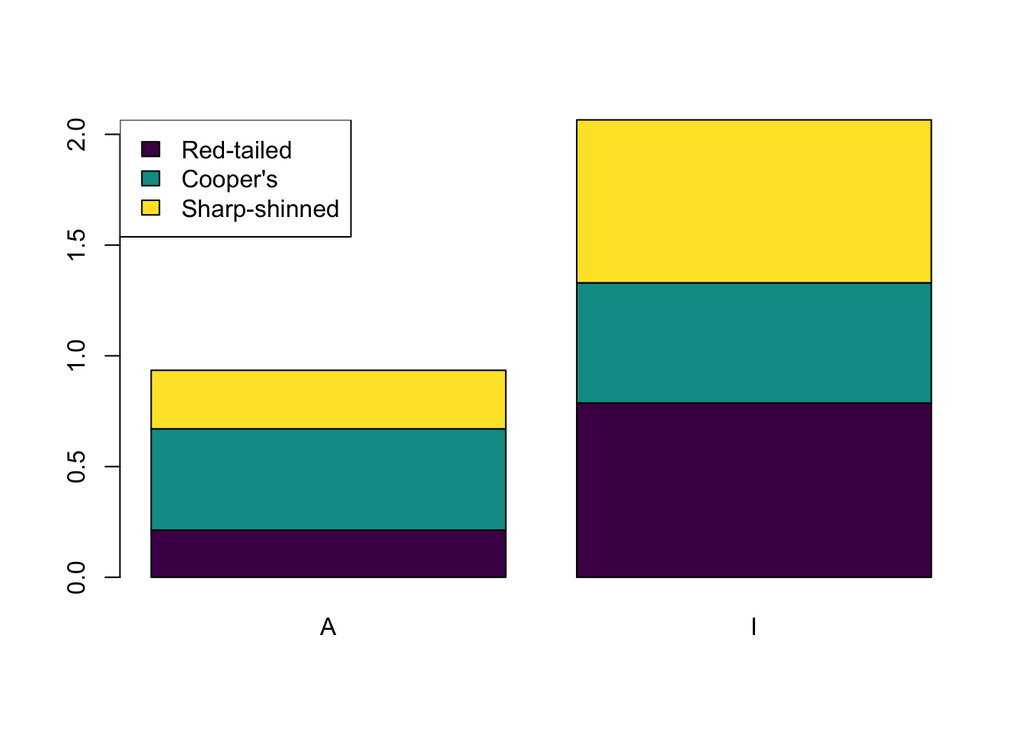

```r
#num_species <- nlevels(hawks$species)  # nlevels() counts number of levels of species

table(hawks$species, hawks$age) |>
  prop.table(1) |>  # prop relative to row (species) totals
  barplot(col = hcl.colors(num_species, palette = "viridis"))

legend(x="topleft",  # place legend in top left
       legend = c("Red-tailed", "Cooper's", "Sharp-shinned"),
       fill = hcl.colors(num_species, palette = "viridis"))
```

**Caution**

In the plot above, the proportions stacked above the immature age group `I` add up to a value greater than 1 which is suspicious for proportions. The command `prop.table(1)` means the proportions are computed relative to the row variable which is species in this case.

- The first rectangle in purple in the `I` stack has height $0.79$ which means $79\%$ of all Red-tailed hawks in the sample are immature.
- Similarly, the green block has height $0.54$ which means $54\%$ of Cooper’s Hawks are immature.
- The yellow block has height $0.74$, so $74\%$ of Sharp-shinned hawks are immature.
- Adding the values together gives a total height of approximately $2.07$

The stacked relative frequency bar plot below is likely a more helpful display since all proportions are relative to each class plotted across the horizontal axis. Thus, the each stack has a height that adds up to one.

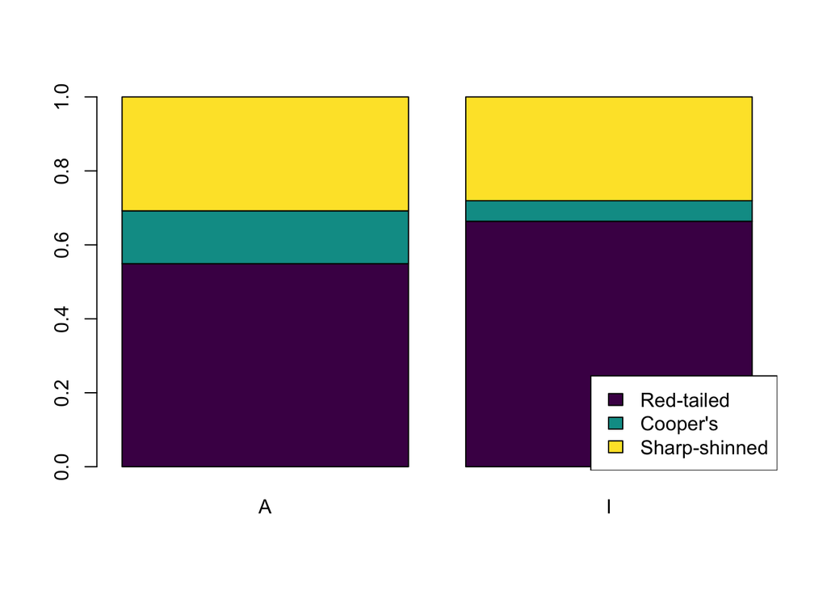

```r
table(hawks$species, hawks$age) |>
  prop.table(2) |>  # prop relative to column (age) totals
  barplot(col = hcl.colors(num_species, palette = "viridis"))  # change color of bars

legend(x="bottomright",  # place legend in bottom right
       legend = c("Red-tailed", "Cooper's", "Sharp-shinned"),
       fill = hcl.colors(num_species, palette = "viridis"))
```

### One Numeric Variable

The generic `base` R `plot()` function will create an index plot with one numeric variable which is often not the best plot for exploring patterns in our data. Histograms, density plots, and/or box plots are better for performing initial data exploration on a single `numeric` variable.

#### Histograms

A **histogram** is special bar chart we use to display the distribution of values for a quantitative variable.

- We first group the values into different ranges of values called **bins** of equal width.
  - This essentially converts the quantitative variable to an ordinal categorical variable with with each bin representing a different level.
- The height of the bars over each bin range is the number of values (or frequency) in each bin range.
- **By default, the counts are right closed.** For example, an HDI value of 0.5 knots would be counted in the bin range 0.4-0.5 and not counted in the bin range 0.5-0.6.
- **The R function `hist(x, [options])` creates a histogram.**
- Run `?hist` for more information about the available options for customizing a histogram, some of which are illustrated in the code cell below.

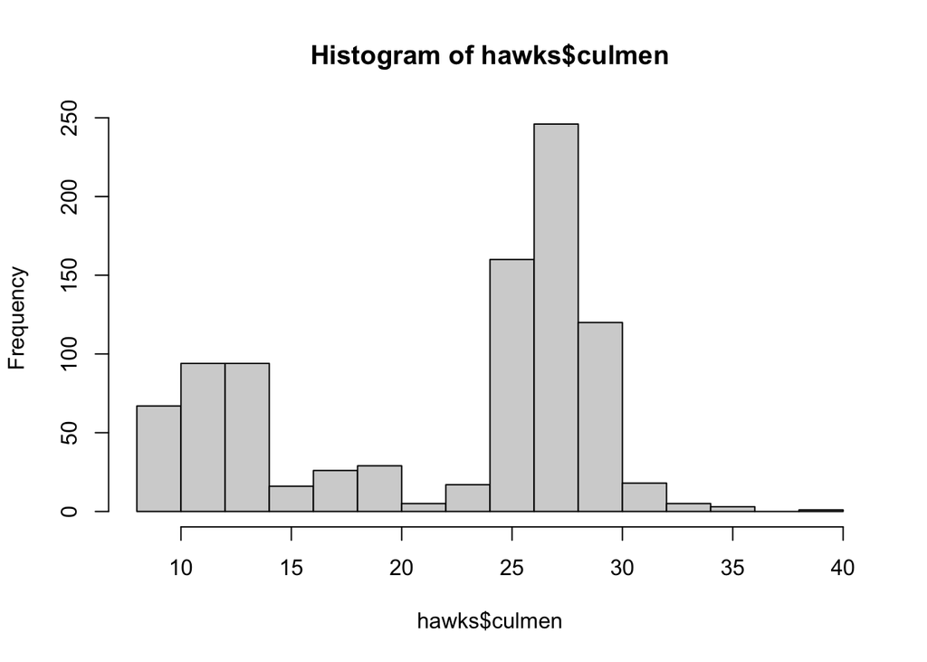

```r
hist(hawks$culmen)
```

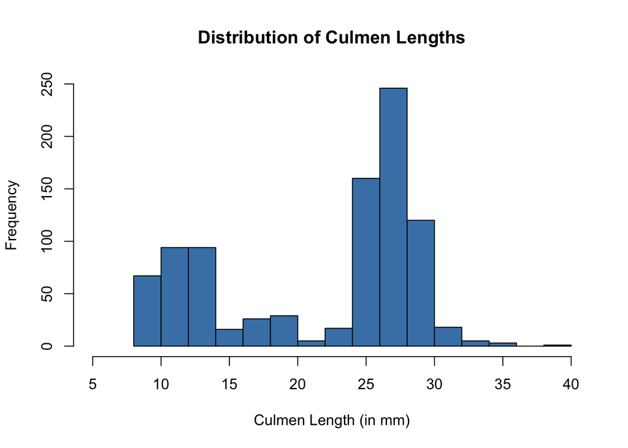

```r
hist(hawks$culmen,  # vector of values to plot
     breaks = 15,  # number of bin ranges to use
     xlab = "Culmen Length (in mm)",   # x-axis label
     xlim = c(5, 40),  # sets window for x-axis
     ylab = "Frequency",  # y-axis label
     ylim = c(0, 250),  # sets window for y-axis
     main = "Distribution of Culmen Lengths",  # main label
     col = "steelblue")  # fill color of bars
```

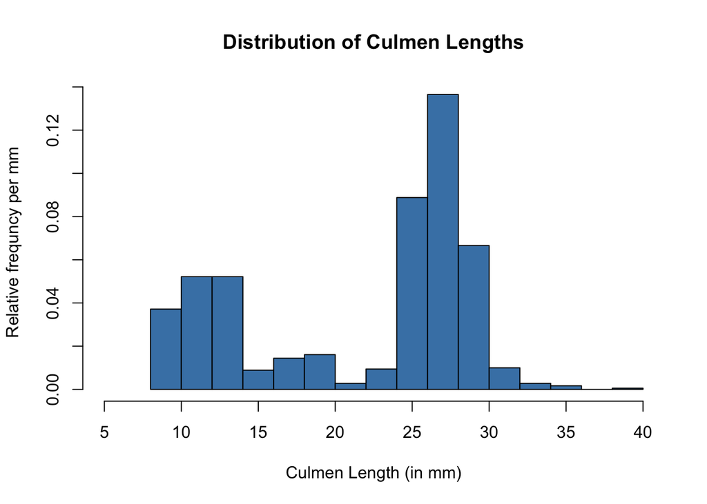

```r
# a relative frequency histogram
hist(hawks$culmen,
     freq = FALSE,  # relative frequency hist
     breaks = 20,
     xlab = "Culmen Length (in mm)",
     xlim = c(5, 40),
     ylab = "Relative frequncy per mm",  # y-axis label
     main = "Distribution of Culmen Lengths",  # main label
     col = "steelblue")  # fill color of bars
```

#### Density Plots

A **density plot** is similar to a smoothed relative frequency histogram.

- The total area under the smoothed curve must equal 1.
- We typically read density plots by approximating the proportion of the total area that lies above a given range of values.
- We need to be careful how we interpret the height, so most people don’t bother!
- On a more surface level, we can identify what seems to be a **bimodal** pattern in the distribution which might be attributed to other **lurking variables**.

We combine the `plot` and `density` functions to construct a density plot using `base` R.

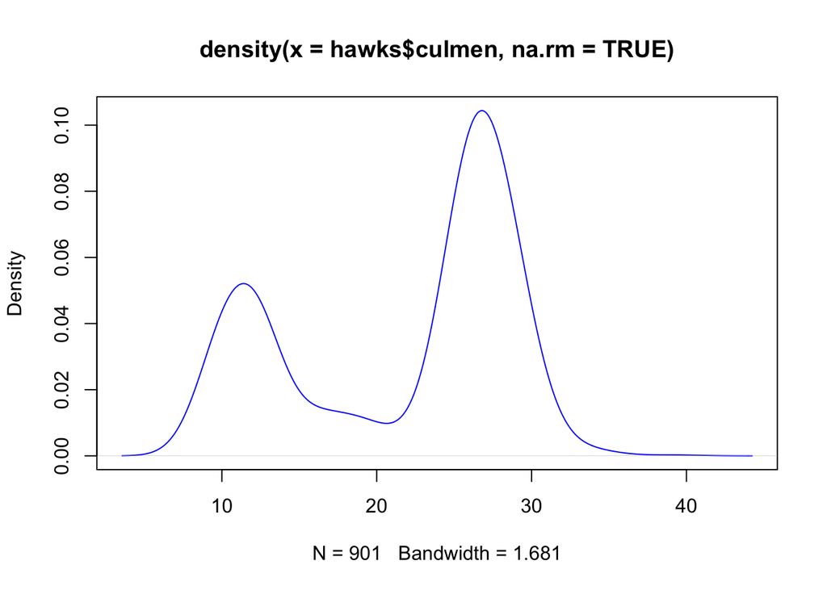

```r
plot(density(hawks$culmen, na.rm = TRUE),
     col = "blue")
```

#### Box Plots

If we align the box plot horizontally:

- A vertical line is drawn at each value in the five number summary. The length of each line should be the same and does not communicate any information.
- Form a rectangle by connecting the top and bottom of the vertical lines corresponding to $Q_1$ and $Q_3$.
  - The median is indicated by the vertical line inside the rectangle.
  - The width of the rectangle equals the interquartile range.
- Extend a horizontal line from the middle of the vertical lines through the minimum to the middle of the vertical line corresponding to $Q_1$.
- Extend a horizontal line from the middle of the vertical lines through the minimum to the middle of the vertical line corresponding to $Q_3$.
- If there are outliers on either side, the process is modified slightly and outliers are indicated with dots.

The `boxplot(x)` function is the easiest approach for producing a single box plot using `base` R.

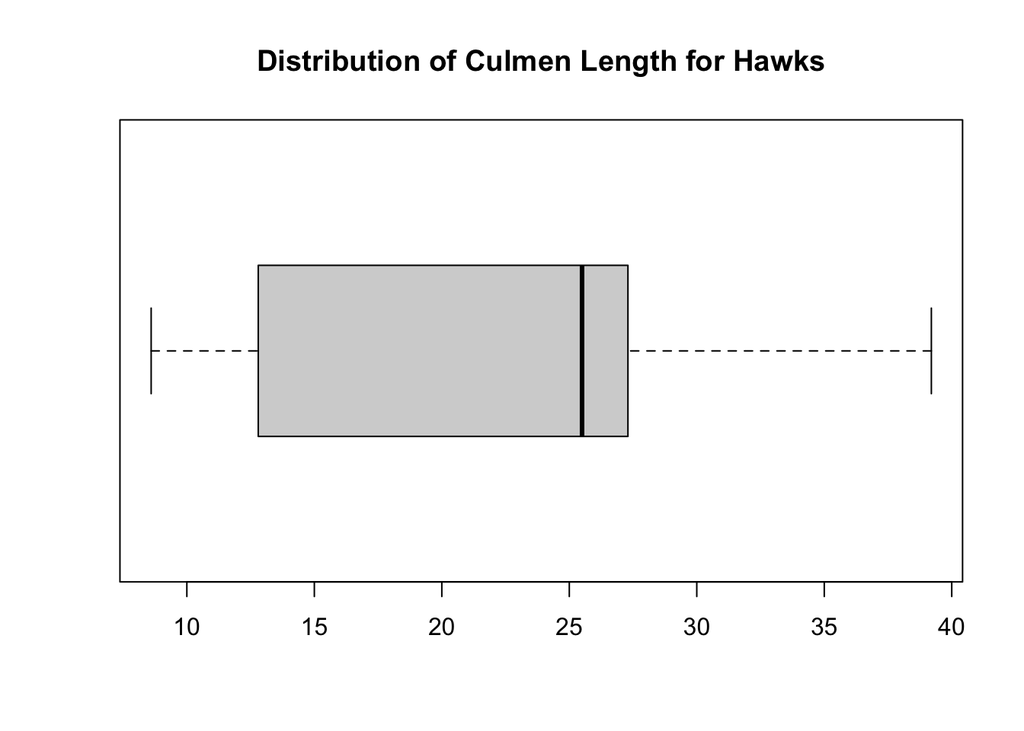

```r
boxplot(hawks$culmen,
        main = "Distribution of Culmen Length for Hawks",
        horizontal = TRUE)
```

### Side-by-Side Box Plots with `boxplot()`

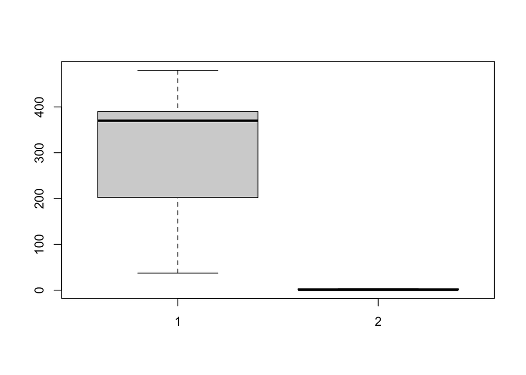

```r
# this does NOT give the desired result
boxplot(hawks$wing, hawks$species)
```

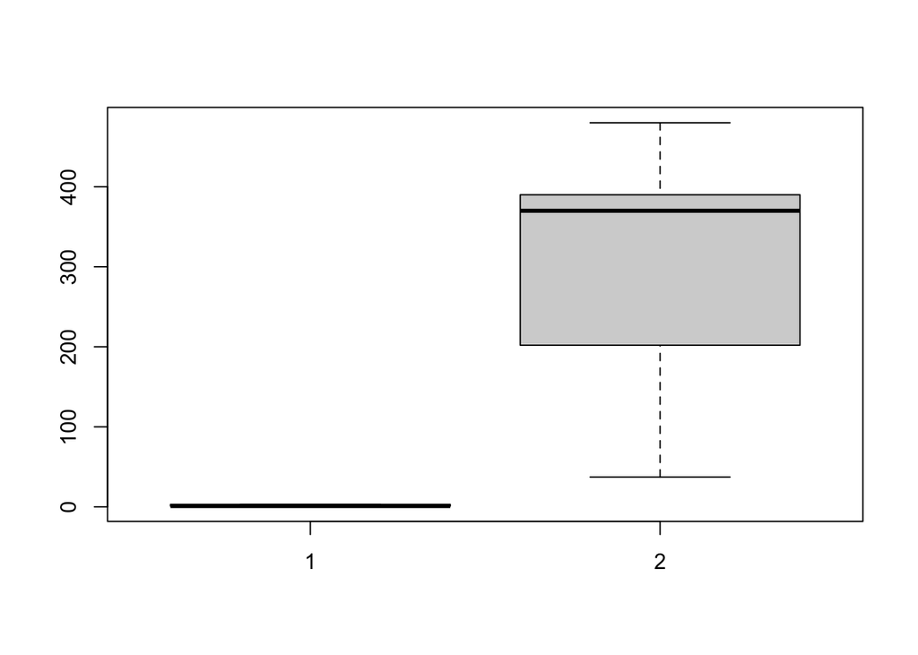

```r
# this does NOT give the desired result
boxplot(hawks$species, hawks$wing)
```

- The response variable is the `numeric` variable `wing`.
- The predictor variable is the `factor` variable `species`.
- The `data` is in `hawks`.

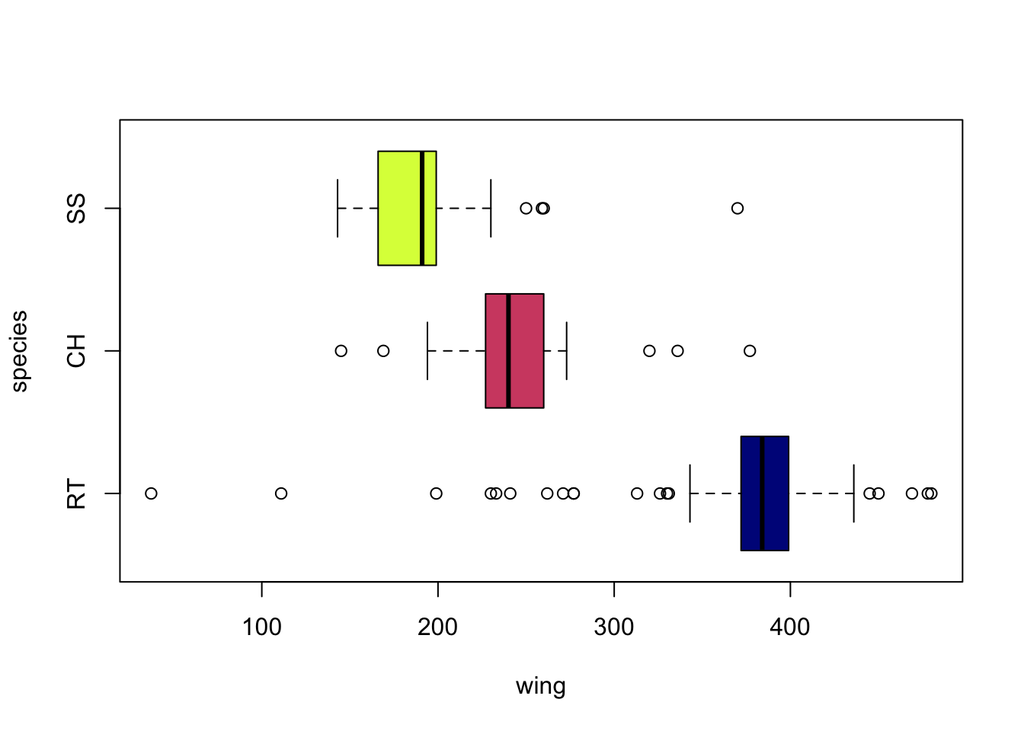

```r
# use the syntax boxplot(response ~ predictor, data = df)
boxplot(wing ~ species,
        data = hawks,
        horizontal = TRUE,  # change layout direction
        col = hcl.colors(3, palette = "plasma"))  # using plasma palette
```